# Predicting Form: or Are You Doing It Right?

Dylan Stark

2017-01-28

## Summary

The purpose of this work is to build a classifier capable of predicting *how well* an individual is performing a given exercise based on readings from attached sensors. We used data for six individuals performing a specific dumbell exercise while wearing multiple sensors. The participants were coached on how to perform the exercise five different ways: the correct way and four common incorrect ways.

In the following sections we will cover how we acquired and explored the data, trained multiple models, and finally chose a classifier and evaluated its out-of-sample error. After preprocessing the data set and tuning our models we were able to find a highly-accurate model, reported at the end or this document.

## Acquiring the Data

The data is available in the [wlehar R package](https://github.com/dylan-stark/wlehar) as clean, tidy data. The training data from `https://d396qusza40orc.cloudfront.net/predmachlearn/pml-training.csv` can be loaded by calling `data(wlehar_jhu_training)` and the test data from `https://d396qusza40orc.cloudfront.net/predmachlearn/pml-testing.csv` can be loaded by calling `data(wlehar_jhu_testing)`. (See [`data-raw/wlehar.R`](https://github.com/dylan-stark/wlehar/blob/master/data-raw/wlehar.R) for details on how the source data was processed.)

```r
data(wlehar_jhu_training)
```

The training data has 19,622 observations of 159 variables and the testing data has 20 observations of those same variables. Since the testing set is so small we will keep that separate from this investigation and generate a new training and testing set by partitioning the original training set.

```r
in_train <- createDataPartition(wlehar_jhu_training$classe, p = 0.70, list = FALSE)
training <- wlehar_jhu_training[in_train, ]
testing <- wlehar_jhu_training[-in_train, ]
```

We use 70% for the new training set and 30% is held out for testing, yielding a training set with 13,737 observations and a testing set with 5,885.

## Preprocessing the Data

A look at the data shows that there are many variables with mostly missing data.

```r
mostly_na_fields <- training %>%
  summarize_all(funs(sum(is.na(.)) / n())) %>%
  gather(measure, percent_na) %>%
  filter(percent_na >= 0.95) %>%
  arrange(measure) %>%
  `[[`("measure")
```

We want to remove these as they will provide very little predictive power and will only negatively impact classifier performance. Of the 159, 100 have more than 95% missing values.

```r
high_corr_fields <- training %>%
  mutate(user_name = as.numeric(as.factor(user_name)),
         cvtd_timestamp = as.numeric(as.factor(cvtd_timestamp)),
         classe = as.numeric(as.factor(classe)),
         new_window = as.numeric(as.factor(new_window))) %>%
  select(-one_of(mostly_na_fields)) %>%
  cor() %>%
  findCorrelation(cutoff = 0.75, names = TRUE)
```

We also want to find and remove highly-correlated variables from consideration. Of the fields that were not mostly missing values, we found 23 highly-correlated fields for removal. That will bring the total number of variables under consideration down to 36.

```r
training_preproc <- training %>%
  select(-one_of(mostly_na_fields), -one_of(high_corr_fields))
testing_preproc <- testing %>%
  select(-one_of(mostly_na_fields), -one_of(high_corr_fields))
```

## Training the Models

Since we have a non-binary response variable we will focus on tree-based classifiers. We’ll use a regression tree model to start. This will help us understand how the data is being split on fields. However, it will not perform particularly well, so we will move on from there to using a random forest approach. In that context we will also evaluate the use of cross-validation to tune the final model.

### Simple Regression Tree

This classifier uses a regression tree model. Bootstrapping (with 25 repititions) is used to find the model fit with the highest accuracy.

```r
rpart_fit <- training_preproc %>%
  train(classe ~ ., data = ., method = "rpart")
rpart_fit
```

```
## CART
##
## 13737 samples
##    35 predictor
##     5 classes: 'A', 'B', 'C', 'D', 'E'
##
## No pre-processing
## Resampling: Bootstrapped (25 reps)
## Summary of sample sizes: 13737, 13737, 13737, 13737, 13737, 13737, ...
## Resampling results across tuning parameters:
##
##   cp          Accuracy   Kappa
##   0.03946699  0.4543572  0.2708154
##   0.04668904  0.4289057  0.2404730
##   0.05101210  0.3772705  0.1592193
##
## Accuracy was used to select the optimal model using  the largest value.
## The final value used for the model was cp = 0.03946699.
```

```r
rpart_fit$finalModel
```

```
## n= 13737
##
## node), split, n, loss, yval, (yprob)
##       * denotes terminal node
##
##   1) root 13737 9831 A (0.28 0.19 0.17 0.16 0.18)
##     2) pitch_forearm< -33.95 1113    7 A (0.99 0.0063 0 0 0) *
##     3) pitch_forearm>=-33.95 12624 9824 A (0.22 0.21 0.19 0.18 0.2)
##       6) total_accel_belt< 20.5 11844 9110 A (0.23 0.22 0.2 0.19 0.15)
##        12) num_window>=46 11258 8524 A (0.24 0.23 0.21 0.19 0.12)
##          24) num_window< 241.5 2635 1346 A (0.49 0.11 0.11 0.18 0.11) *
##          25) num_window>=241.5 8623 6284 B (0.17 0.27 0.24 0.19 0.12)
##            50) roll_dumbbell< -88.63869 1179  443 C (0.12 0.19 0.62 0.042 0.021) *
##            51) roll_dumbbell>=-88.63869 7444 5331 B (0.17 0.28 0.18 0.22 0.14)
##             102) yaw_dumbbell>=-63.95527 4121 2521 B (0.2 0.39 0.08 0.18 0.15)
##               204) total_accel_dumbbell< 5.5 1701  970 A (0.43 0.16 0.1 0.27 0.037) *
##               205) total_accel_dumbbell>=5.5 2420 1092 B (0.037 0.55 0.065 0.11 0.24) *
##             103) yaw_dumbbell< -63.95527 3323 2283 C (0.15 0.15 0.31 0.26 0.12) *
##        13) num_window< 46 586  106 E (0 0 0 0.18 0.82) *
##       7) total_accel_belt>=20.5 780   82 E (0.085 0.021 0 0 0.89) *
```

Looking at the tree we see that the splits go through phases of movement- and time-based measurements. This fits well with our intuitive sense of how a trainer would watch for particular movements at different times throughout the performance of an exercise. Unfortunately, the in-sample accuracy for the best model fit is rather low at 0.45.

### Random Forest with Cross-Validation

Given the high in-sample error rate when using a simple regression tree we will now try a random forest approach. For this we will use the `trainControl()` function with `method = "cv"` and `p = 0.70` to do cross-validation with 70% of the data used for training. We also varied the `k` parameter from 2 to 10. The comparison of accuracy for different values of `k` and `mtry` is shown below.

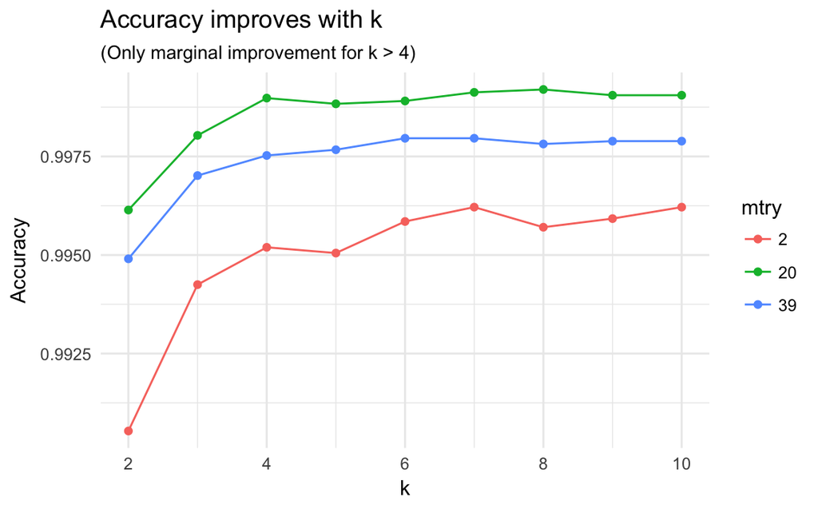

Given the marginal improvements in accuracy, we choose to use 7 folds to balance (in-sample) accuracy, bias, and variance. The summary for the 7-fold model and (in-sample) confusion matrix are show below.

```
## Random Forest
##
## 13737 samples
##    35 predictor
##     5 classes: 'A', 'B', 'C', 'D', 'E'
##
## No pre-processing
## Resampling: Cross-Validated (7 fold)
## Summary of sample sizes: 11773, 11775, 11774, 11774, 11776, 11776, ...
## Resampling results across tuning parameters:
##
##   mtry  Accuracy   Kappa
##    2    0.9962149  0.9952120
##   20    0.9991264  0.9988951
##   39    0.9979620  0.9974223
##
## Accuracy was used to select the optimal model using  the largest value.
## The final value used for the model was mtry = 20.
```

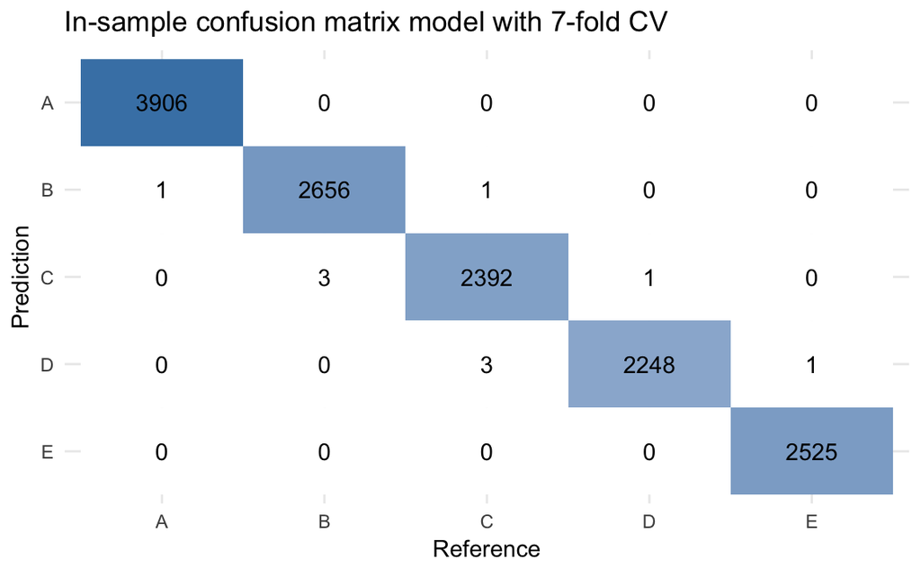

## Evaluating Out-of-sample Error

The final model we chose, with 7-fold cross-validataion, had a good in-sample accuracy of 1. But now we need to use the testing set that was held out earlier to evaluate the out-of-sample error. The following shows that the classifier performs on the testing data, too, and so we can confidently rely on it to classify *how well* these individuals are preforming this exercise using new data.

```r
rf_cv_confusion <- rf_cv_k[[k_final]] %>%
  predict(testing_preproc) %>%
  confusionMatrix(testing_preproc$classe)
```

```
## Confusion Matrix and Statistics
##
##           Reference
## Prediction    A    B    C    D    E
##          A 1674    0    0    0    0
##          B    0 1139    2    0    0
##          C    0    0 1022    0    0
##          D    0    0    2  963    1
##          E    0    0    0    1 1081
##
## Overall Statistics
##
##                Accuracy : 0.999
##                  95% CI : (0.9978, 0.9996)
##     No Information Rate : 0.2845
##     P-Value [Acc > NIR] : < 2.2e-16
##
##                   Kappa : 0.9987
##  Mcnemar's Test P-Value : NA
##
## Statistics by Class:
##
##                      Class: A Class: B Class: C Class: D Class: E
## Sensitivity            1.0000   1.0000   0.9961   0.9990   0.9991
## Specificity            1.0000   0.9996   1.0000   0.9994   0.9998
## Pos Pred Value         1.0000   0.9982   1.0000   0.9969   0.9991
## Neg Pred Value         1.0000   1.0000   0.9992   0.9998   0.9998
## Prevalence             0.2845   0.1935   0.1743   0.1638   0.1839
## Detection Rate         0.2845   0.1935   0.1737   0.1636   0.1837
## Detection Prevalence   0.2845   0.1939   0.1737   0.1641   0.1839
## Balanced Accuracy      1.0000   0.9998   0.9981   0.9992   0.9994
```

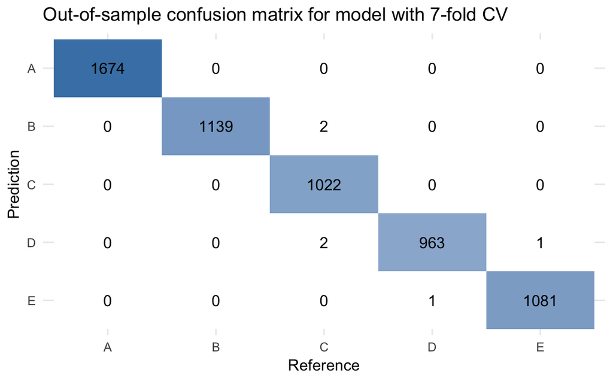